# Santiago Linear Regression

Thompson Santiago

2026-07-06

# Set-up Phase

*Libraries to be used, I don’t think anything special for this one, also trying something new and that is to code directly in the .rmd file (used to copy-paste everything over but found that .rmd has some nice UI inclusions)*

```r
library(tidyverse)
library(terra)
```

# A. Simple Linear Regression

*For this portion, I decided on acting out of question order after giving it a read through as it was essentially just one straight motion.*

```r
# 2. Read in the species data and remove unnecessary rows with NAs.
herp_csv <- read.csv("C:/DLSU/25-26/[4] LBBBI27/activities/a03/herpetozoa-033-095-s001.csv")
herp_data <- herp_csv[complete.cases(herp_csv),]

# 4.1 From the species data, subset the longitude and latitude coordinates.
herp_spat <- herp_data[,c(2,3)]
class(herp_spat)
```

```
## [1] "data.frame"
```

```r
# 4.2 Then convert the coordinates to a spatial vector using the “vect” function from the “terra” package.
herp_vect <- vect(herp_spat, geom=c("Long","Lat"))
```

*This code block is dedicated to read-ins and establishment of supplementary data and data variables.*

```r
# 3. Read in the elevation data (ph_strm_geo.tif).
elev_data <- rast("C:/DLSU/25-26/[4] LBBBI27/activities/a10/ph_ strm_geo.tif")

# 5. Using the converted coordinates, extract elevation data for each point with the “extract” function in the “terra” package.
# (The extracted data will have two columns: “ID” and “Band_1.” The “Band_1” column contains the elevation.)
elev_extr <- extract(elev_data, herp_vect)

# 6.1 Subset the species data to retain only the species richness column (SPPTotal).
herp_rich <- matrix(herp_data[,6])

# 6.2 Then combine this column with the extracted elevation. Rename “Band_1” to “elevation.
herp_elev <- cbind(elev_extr, herp_rich)
herp_elev <- rename(herp_elev, "Elevation" = "Band_1")
```

*Using the fruits of the previous code locks to do number stuff! Single linear regression for now for part A.* *In single quotes, my thoughts. In comments, the assignment instructions.*

```r
# 7.1 Now, perform simple linear regression using the code from the pre-lab lecture,
'Raw values assigned to variable names for convenience'
```

```
## [1] "Raw values assigned to variable names for convenience"
```

```r
slr_x <- herp_elev[,2]
slr_y <- herp_elev[,3]

xb <- mean(slr_x)
yb <- mean(slr_y)

'Secondary-level variables'
```

```
## [1] "Secondary-level variables"
```

```r
b <- sum((slr_x - xb) * (slr_y - yb)) / sum((slr_x - xb)^2)
a <- yb - b*xb

'Write the equation (I guess this will help with understanding what\'s going on'
```

```
## [1] "Write the equation (I guess this will help with understanding what's going on"
```

```r
cat("Regression Equation:\n")
```

```
## Regression Equation:
```

```r
cat("y =", round(a,3), "+", round(b,3), "x\n")
```

```
## y = 4.176 + -0.004 x
```

```r
'Looks about right, setting it'
```

```
## [1] "Looks about right, setting it"
```

```r
yhat <- a + b * slr_x

slr_data <- data.frame(
  "Elevation" = slr_x,
  "Species Richness" = slr_y,
  "Predicted" = round(yhat, 2)
)
```

*Who up plotting?*

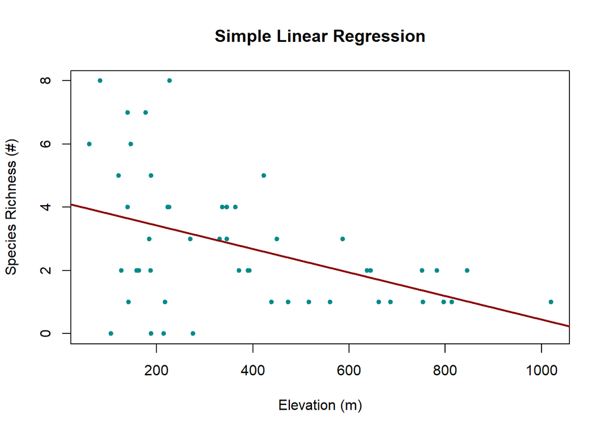

```
## integer(0)
```

```r
# 7.2 including a plot.
plot(herp_elev$"Elevation", herp_elev$"herp_rich",
     pch = 20,
     col = "darkcyan",
     xlab = "Elevation (m)",
     ylab = "Species Richness (#)",
     main = "Simple Linear Regression") +
abline(a, b,
       col = "darkred",
       lwd = 2)
```

```r
# 7.3 What can you infer about the relationship between species and elevation?
'The single linear regression model observes and predicts decreases in species richness as elevation increases.'
```

```
## [1] "The single linear regression model observes and predicts decreases in species richness as elevation increases."
```

# B. Multiple Linear Regression

*Read-ins of x-vars beyond the first.*

```r
# 1. Read in both annual precipitation and temperature data and extract the data following the instructions from A4–5.
ph_temps <- rast("C:/DLSU/25-26/[4] LBBBI27/activities/a03/annual_temperature.tif")
temp_extr <- extract(ph_temps, herp_vect)

ph_preci <- rast("C:/DLSU/25-26/[4] LBBBI27/activities/a03/annual_precipitation.tif")
preci_extr <- extract(ph_preci, herp_vect)
```

*C-Bind into one dataframe.*

```r
# 2. Combine the extracted data with the species and elevation data into a single dataframe.
herp_multi <- cbind(herp_elev$Elevation, temp_extr$annual_temperature, preci_extr$annual_precipitation)
herp_multi <- data.frame(herp_multi)
herp_multi <- rename(herp_multi, "Elevation" = "X1", "Annual Temperature" = "X2", "Annual Precipitation" = "X3")
class(herp_multi)
```

```
## [1] "data.frame"
```

*Multiple linear regression*

```r
# 3. Perform multiple linear regression using the “lm” function.
m_model <- lm(herp_elev$"herp_rich" ~ herp_multi$"Elevation" + herp_multi$"Annual Temperature" + herp_multi$"Annual Precipitation")

coef(m_model)
```

```
##                       (Intercept)              herp_multi$Elevation
##                      76.724668071                      -0.003624483
##   herp_multi$"Annual Temperature" herp_multi$"Annual Precipitation"
##                      -1.397486338                      -0.021655249
```

```r
ma <- coef(m_model)[1]
m1 <- coef(m_model)[2]
m2 <- coef(m_model)[3]
m3 <- coef(m_model)[4]

cat("y =", round(ma,3), "+", round(m1,3), "x1", "+", round(m2,3), "x2", "+", round(m3,3), "x3")
```

```
## y = 76.725 + -0.004 x1 + -1.397 x2 + -0.022 x3
```

```r
m_yhat <- predict(m_model) |> data.frame()
print(m_yhat)
```

```
##    predict.m_model.
## 1        1.94648854
## 2        2.16758198
## 3        1.98747131
## 4        2.29192784
## 5        0.74421403
## 6        0.41076163
## 7        0.32269431
## 8        0.70260655
## 9        2.66444048
## 10       3.11752193
## 11       2.83481229
## 12       2.63486324
## 13       2.12136327
## 14       1.81086313
```

[output cut: 35 more lines]

```r
summary(m_model)
```

```
##
## Call:
## lm(formula = herp_elev$herp_rich ~ herp_multi$Elevation + herp_multi$"Annual Temperature" +
##     herp_multi$"Annual Precipitation")
##
## Residuals:
##     Min      1Q  Median      3Q     Max
## -2.9599 -1.1531 -0.0372  0.6773  5.8759
##
## Coefficients:
##                                    Estimate Std. Error t value Pr(>|t|)
## (Intercept)                       76.724668  26.354033   2.911  0.00558 **
## herp_multi$Elevation              -0.003624   0.002970  -1.221  0.22863
## herp_multi$"Annual Temperature"   -1.397486   0.627803  -2.226  0.03107 *
## herp_multi$"Annual Precipitation" -0.021655   0.009518  -2.275  0.02770 *
## ---
## Signif. codes:  0 '***' 0.001 '**' 0.01 '*' 0.05 '.' 0.1 ' ' 1
##
## Residual standard error: 1.801 on 45 degrees of freedom
## Multiple R-squared:  0.3084, Adjusted R-squared:  0.2623
## F-statistic: 6.689 on 3 and 45 DF,  p-value: 0.0007873
```

```r
# 4. Which relationship is statistically significant?
'Based on the summary of m_model (var name for multiple linear regression model), the annual temperature and annual precipitation of a location is significantly related to its species richness. This is not true of elevation of the place.'
```

```
## [1] "Based on the summary of m_model (var name for multiple linear regression model), the annual temperature and annual precipitation of a location is significantly related to its species richness. This is not true of elevation of the place."
```

*Okay that’s all I have. I still don’t know how to generate maps so I will have to submit a new version after all my technical issues are resolved and I learn how to use what I’ve not been able to learn so far.*